# Il Giro d'Italia negli ultimi 35 anni

Progetto di Thomas Casasola

# Perché 35

2 motivazioni principali:

- Evoluzione tecnologica
- Tecniche di allenamento e di gara

# Nascita del progetto

- Ex ciclista agonistico
- Curiosità personale

Domande che mi sorgono a riguardo:

- Quanto è cambiato il giro d'italia negli anni a venire?
- Quali sono le caratteristiche fische che i corridori devono avere?
- Quali nazioni e squadre sono le piu vincenti?

# Dataset utilizzati

Per lo sviluppo del progetto sono stati usati:

- InfoGiro.csv(creato)
- CorridoriGiro.csv(creato)

Con informazioni tratte da:

- ProCyclingStats
- Wikipedia

# Andamento del Giro d'Italia

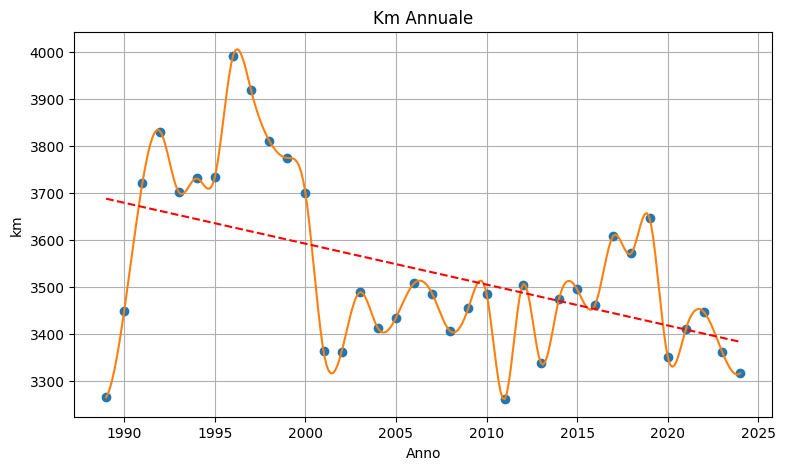

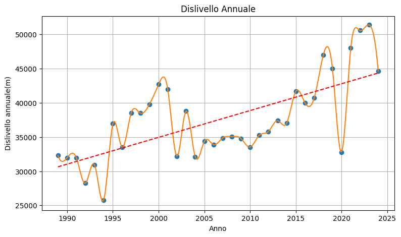

il 2020 mostra un decremento a causa del COVID-19

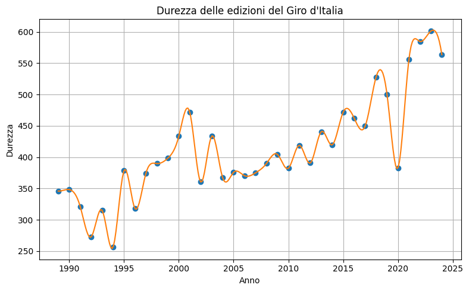

Permette di capire la variazione di difficolta negli anni nonostante i km diminuiti

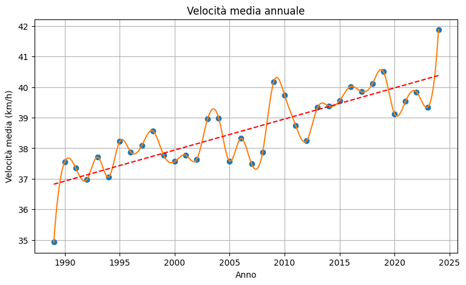

Km/TempoTot otteniamo la velocita media, osserviamo come ha tendenza linearmente positiva

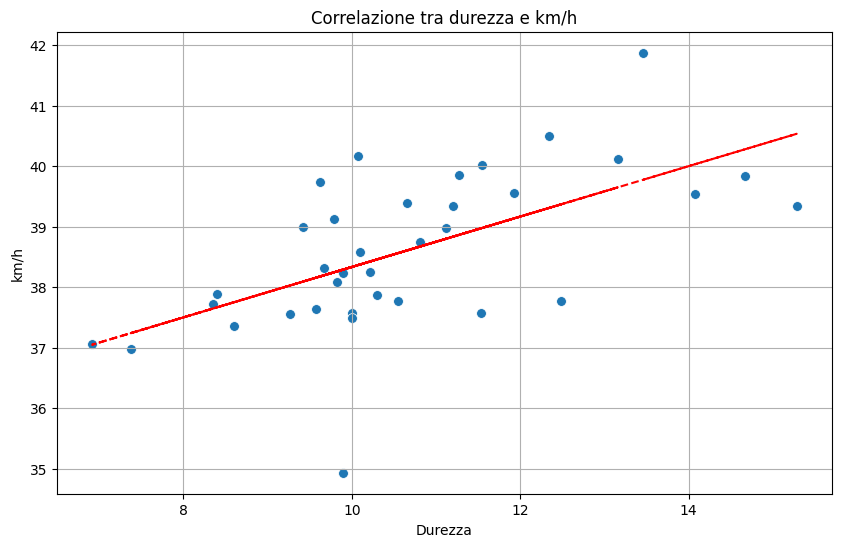

```
Coefficiente di correlazione: 0.61
```

Tendendo sempre in cosiderazione la durezza con Dislivello/KmTotali

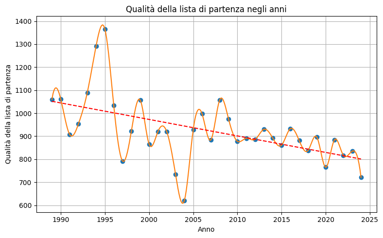

Punteggio: top10: 50, top25: 35, top50: 20, top100: 10, top200: 5, top500: 2, top1000: 1

# Caratteristiche dei corridori

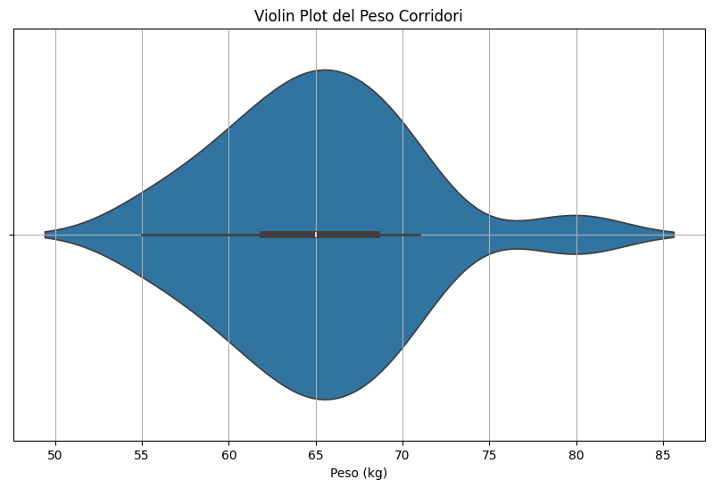

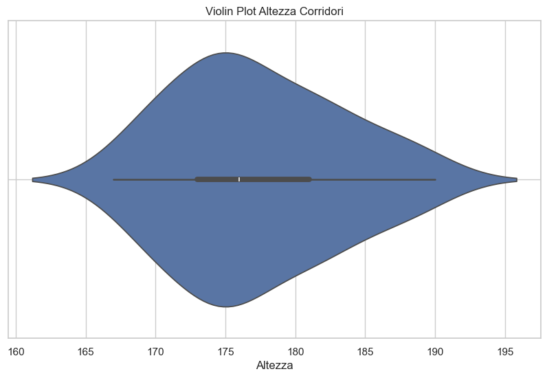

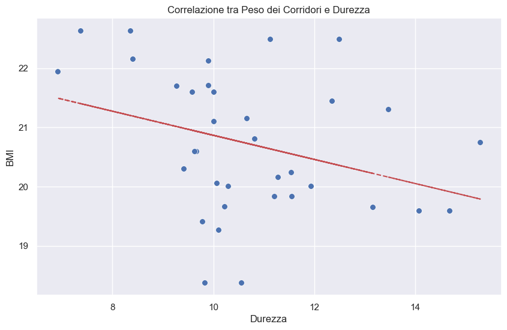

```
Coefficiente di correlazione: -0.32
```

BMI: peso/altezza^2

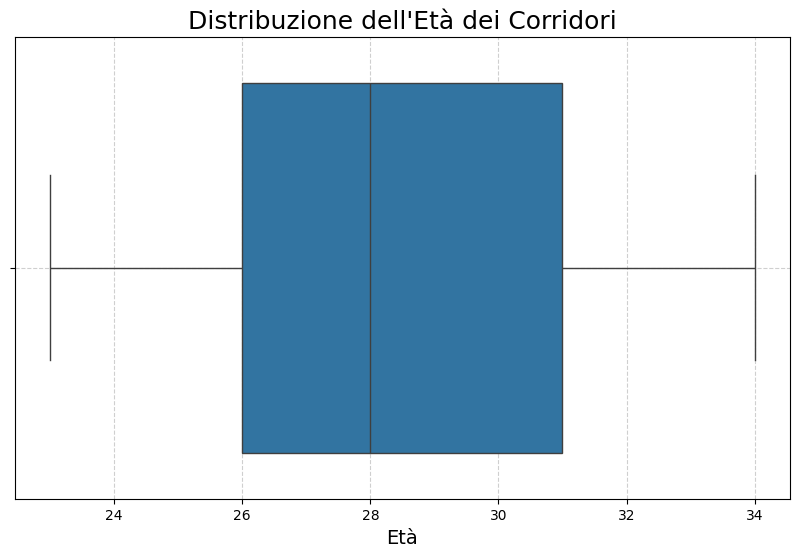

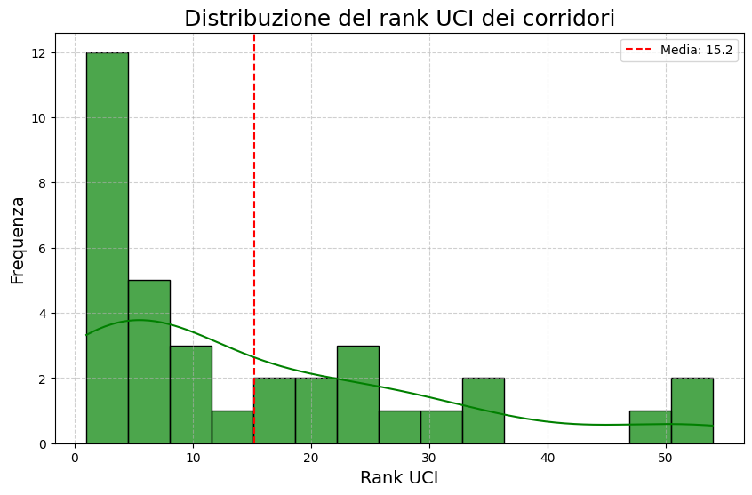

Corridore vincente ha piu possibilita di vittoria

# Chi ha vinto di piu?

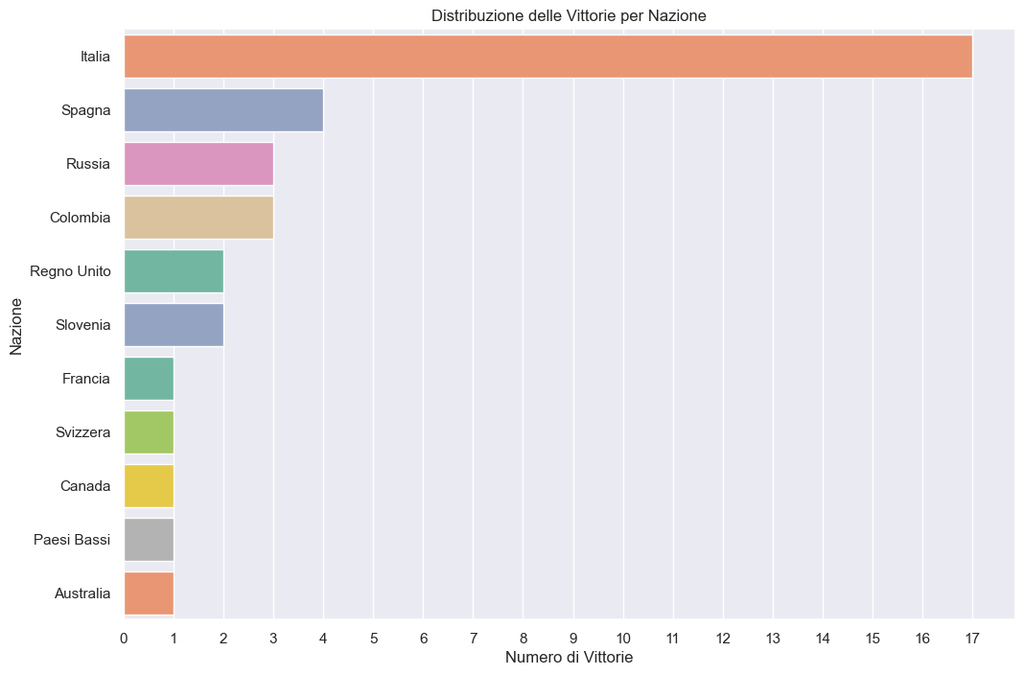

Possiamo osservare come l'Italia sia stato un tassello importante conquistando diverse edizioni,

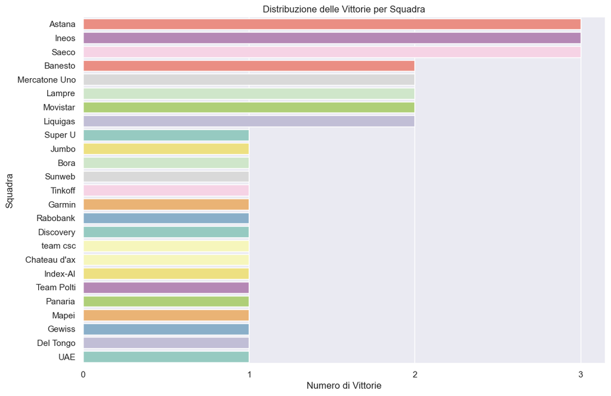

Astana Ineos Saeco conquistano entrambe 3 edizioni

# Ricapitolando

- Giro sta avendo riduzione dei km e maggiore dislivello, quindi sempre piu duro con aumento velocita media, con coefficente di correlazione di 0.61, . Qualita dei partenti sta riducendo nonostante le prestazioni maggiori, con il rischio di monopolizzazione
- Caratteristiche di un corridore sono 176cm per 65kg di peso, con aumento durezza si ha un calo di BMI, media eta di vittoria 28 anni,
- Nazione piu vincente e l'Italia mentre le squadre piu vincenti sono 3 a parimerito: Astana,Ineos e Saeco